# Interpretable Machine Learning: Shapley values

Karl Ho

2022-05-04

[figure not shown]

Prediction model for Taiwan presidential elections in 2016: predicting Tsai voters

## Introduction

Machine learning models are not created for straignt-forward, easy interpretation in the first place. Predictive models from SVM, random forest, xgboost, deep learning give a certain prediction with accuracy rate but not explanable, not to mention the importance of individual features.

Recent research by [Lundberg and Lee 2017](https://proceedings.neurips.cc/paper/2017/file/8a20a8621978632d76c43dfd28b67767-Paper.pdf) and [Christoph Molner 2022](https://christophm.github.io/interpretable-ml-book/) provides new techniques to interpret black-box models. One useful tool is Shapley values [SHAP](https://github.com/slundberg/shap) (**SH**apley **A**dditive ex**P**lanations) developed by Scott M. Lundberg.

SHAP measures the impact of variables taking into account the interaction with other variables.

> Shapley values calculate the importance of a feature by comparing what a model predicts with and without the feature. However, since the order in which a model sees features can affect its predictions, this is done in every possible order, so that the features are fairly compared.

[Source: Gabriel Tseng. 2018. *Interpreting complex models with SHAP values*, Medium](https://medium.com/@gabrieltseng/interpreting-complex-models-with-shap-values-1c187db6ec83)

## Shapley values in R (shapper package)

```r
# Preparing data
library(tidyverse)
teds2016 = read_csv("https://raw.githubusercontent.com/kho7/issuevoting/master/TEDS2016_issueset.csv")
teds2016$votetsai_nm=factor(teds2016$votetsai_nm)
teds2016$female=factor(teds2016$female)
teds2016 <- na.omit(teds2016)
# teds2016sm=c("votetsai_nm","age", "unify", "indep","income_nm", "taiwanese","female","south","whitecollar","dadminnan","dadmainland","econworse", "inequality","pubwelf")
teds2016sm=c("votetsai_nm","age","kmt","dpp","npp", "statusquo","income_nm", "taiwanese","female","south","whitecollar","dadminnan","dadmainland","econworse", "inequality","pubwelf")
summary(teds2016sm)
```

```
##    Length     Class      Mode
##        16 character character
```

```r
vote2016 <- teds2016[teds2016sm]
```

```r
# install.packages("randomForest")
library(randomForest)
# Build Random Forest model
set.seed(123)
model_rfdpp <- randomForest(votetsai_nm ~ .  , data = vote2016)
model_rfdpp
```

```
##
## Call:
##  randomForest(formula = votetsai_nm ~ ., data = vote2016)
##                Type of random forest: classification
##                      Number of trees: 500
## No. of variables tried at each split: 3
##
##         OOB estimate of  error rate: 13.04%
## Confusion matrix:
##     0   1 class.error
## 0 332  82  0.19806763
## 1  54 575  0.08585056
```

```r
# Create profile
# Note: must be same order and same data types
new_voter1 <- data.frame(
  age = 30,
  kmt=0,
  dpp=1,
  npp=0,
  statusquo=0,
  income_nm=7,
  taiwanese=1,
  female = factor("1", levels = c("1","0")),
  south = 1,
  whitecollar=1,
  dadminnan=1,
  dadmainland=0,
  econworse = 1,
  inequality=1,
  pubwelf=0)
predict(model_rfdpp, new_voter1, type = "prob")
```

```
##       0     1
## 1 0.012 0.988
## attr(,"class")
## [1] "matrix" "array"  "votes"
```

```r
#install.packages("DALEX")
library(DALEX)
# install_dependencies()

exp_rf <- explain(model_rfdpp, data = vote2016[,-1])
```

[output not shown]

```r
exp_rf
```

```
## Model label:  randomForest
## Model class:  randomForest.formula,randomForest
## Data head  :
##   age kmt dpp npp statusquo income_nm taiwanese female south whitecollar
## 1  39   0   0   0         0         7         0      1     0           1
## 2  63   1   0   0         1         8         0      0     0           1
##   dadminnan dadmainland econworse inequality pubwelf
## 1         1           0         0          1       1
## 2         1           0         1          1       1
```

```r
library(shapper)
library(tictoc)
tic() # Checking time
ive_rf <- shap(exp_rf, new_observation = new_voter1)
toc()
```

```
## 149.489 sec elapsed
```

```r
ive_rf
```

```
##     age kmt dpp npp statusquo income_nm taiwanese female south whitecollar
## 1    30   0   1   0         0         7         1      1     1           1
## 1.1  30   0   1   0         0         7         1      1     1           1
## 1.2  30   0   1   0         0         7         1      1     1           1
## 1.3  30   0   1   0         0         7         1      1     1           1
## 1.4  30   0   1   0         0         7         1      1     1           1
## 1.5  30   0   1   0         0         7         1      1     1           1
##     dadminnan dadmainland econworse inequality pubwelf _id_ _ylevel_ _yhat_
## 1           1           0         1          1       0    1           0.988
## 1.1         1           0         1          1       0    1           0.988
## 1.2         1           0         1          1       0    1           0.988
## 1.3         1           0         1          1       0    1           0.988
## 1.4         1           0         1          1       0    1           0.988
## 1.5         1           0         1          1       0    1           0.988
##     _yhat_mean_   _vname_ _attribution_ _sign_      _label_
## 1     0.6087037       age   0.002033902      + randomForest
## 1.1   0.6087037       kmt   0.120840995      + randomForest
## 1.2   0.6087037       dpp   0.153364529      + randomForest
## 1.3   0.6087037       npp   0.000000000      - randomForest
## 1.4   0.6087037 statusquo   0.024194586      + randomForest
## 1.5   0.6087037 income_nm   0.000000000      - randomForest
```

```r
class(ive_rf)
```

```
## [1] "individual_variable_effect" "data.frame"
```

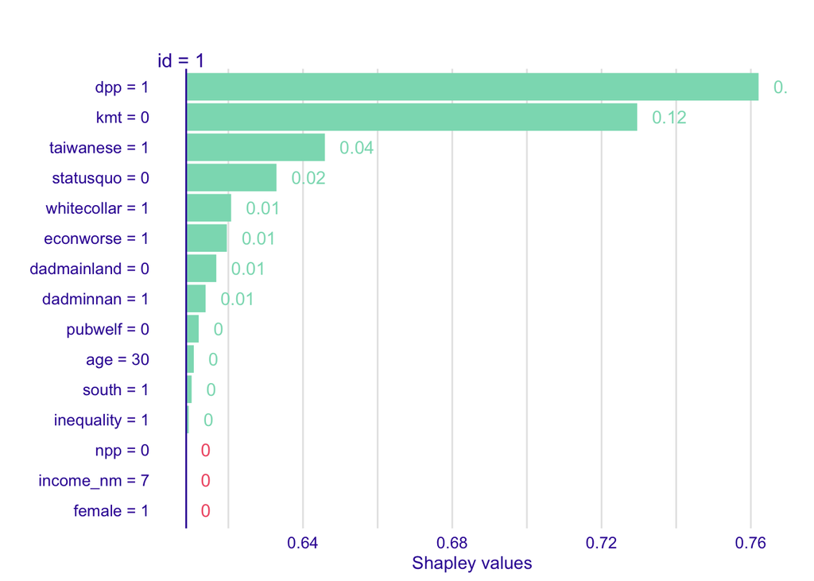

```r
plot(ive_rf, show_predicted = FALSE)
```

```r
library(e1071)
model_svm <- svm(votetsai_nm~. , data = vote2016, probability = TRUE)
model_svm
```

```
##
## Call:
## svm(formula = votetsai_nm ~ ., data = vote2016, probability = TRUE)
##
##
## Parameters:
##    SVM-Type:  C-classification
##  SVM-Kernel:  radial
##        cost:  1
##
## Number of Support Vectors:  415
```

```r
attr(predict(model_svm, newdata = new_voter1, probability = TRUE), "probabilities")
```

```
##           1         0
## 1 0.9151745 0.0848255
```

```r
exp_svm <- explain(model_svm, data = vote2016[,-1])
```

[output not shown]

```r
tic()
ive_svm <- shap(exp_svm, new_voter1)
toc()
```

```
## 61.858 sec elapsed
```

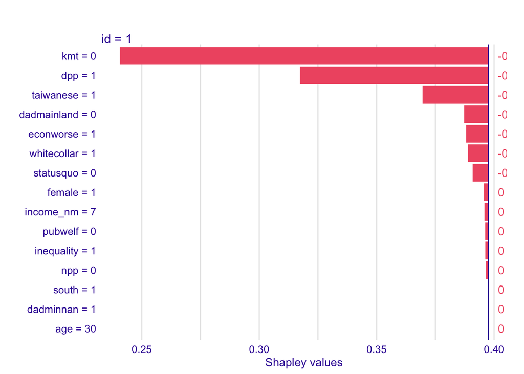

```r
plot(ive_svm, show_predicted = FALSE)
```

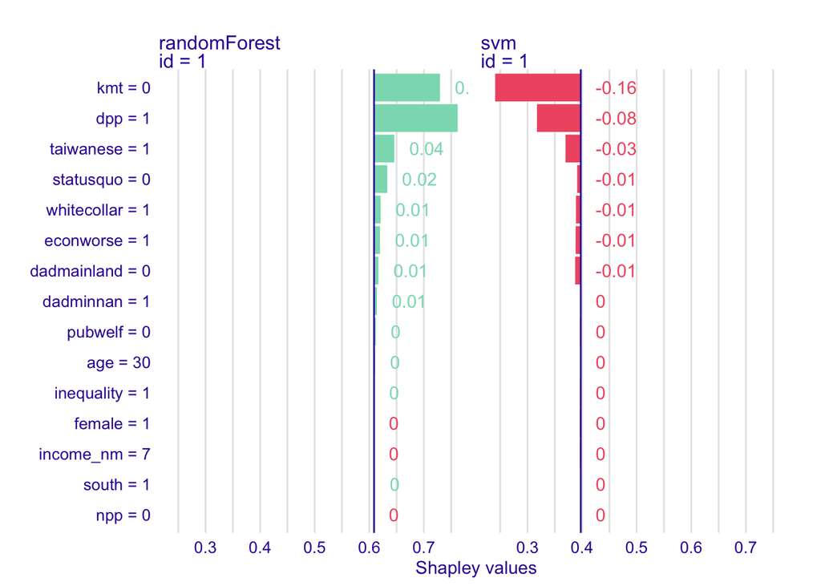

```r
plot(ive_rf, ive_svm, show_predicted = FALSE)
```

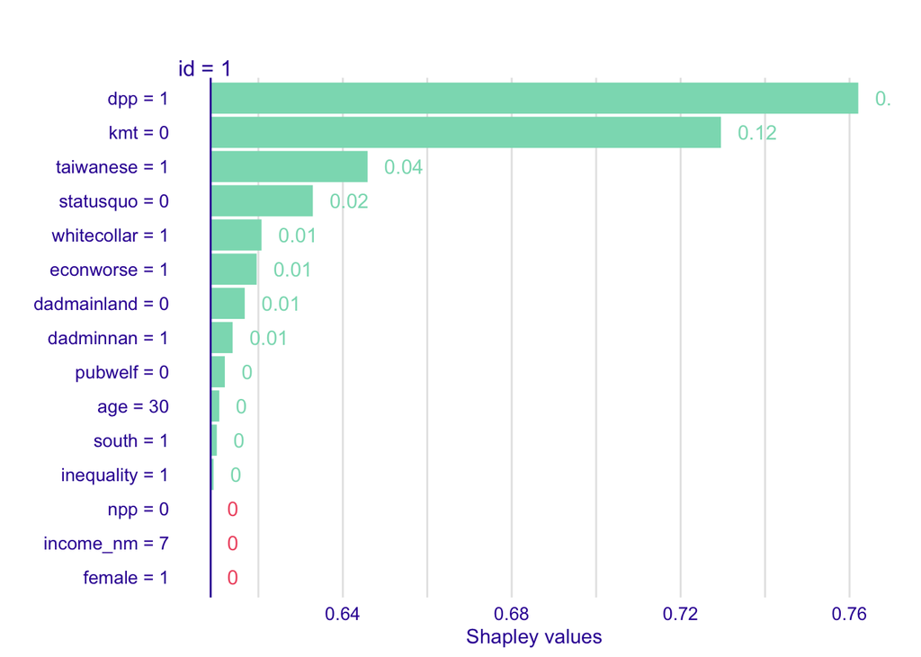

```r
plot(ive_rf, show_predicted = FALSE)
```

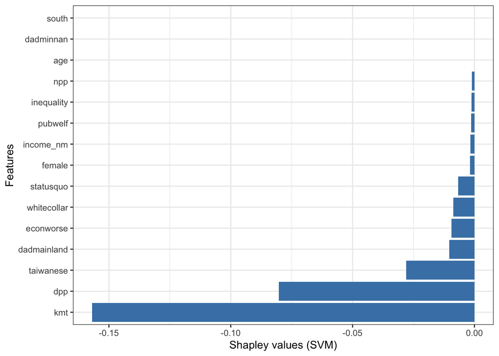

```r
ive_svmdf=ive_svm
ive_svmdf$features=ive_svmdf$'_vname_'
ive_svmdf$attributions=ive_svmdf$'_attribution_'

# Plot Shapley values (SVM) using ggplot2

library(tidyverse)
ive_svmdf %>%
  mutate(features=fct_reorder(features,attributions)) %>%
  ggplot(aes(x=attributions, y=features)) +
  geom_bar(stat="identity", fill = "steelblue") +
  theme_bw() +
  xlab("Shapley values (SVM)") + ylab("Features")
```

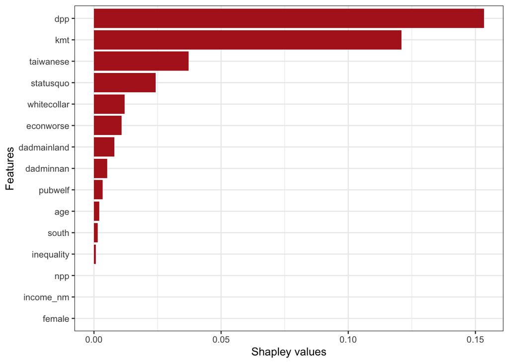

```r
ive_rfdf=ive_rf
ive_rfdf$features=ive_rfdf$'_vname_'
ive_rfdf$attributions=ive_rfdf$'_attribution_'
# Creating attrib variable from ive objects
ive_rfdf$attrib =as.numeric(paste(ive_rfdf$'_sign_',ive_rfdf$attributions,sep=""))

# Plot Shapley values (Random Forest) using ggplot2
ive_rfdf %>%
  mutate(features=fct_reorder(features,attrib)) %>%
  ggplot(aes(x=attributions, y=features)) +
  geom_bar(stat="identity", fill = "firebrick") +
  theme_bw() +
  xlab("Shapley values") + ylab("Features")
```

### Interpreting the Shapley value plot?

- The y-axis indicates the feature names, in order of importance from top to bottom.
- On the x-axis is the Shapley value. Indicates how much is the change in probability of success in prediction.

## R packages with SHAP

**[Interpretable Machine Learning](https://cran.r-project.org/web/packages/iml/vignettes/intro.html)** by Christoph Molnar.

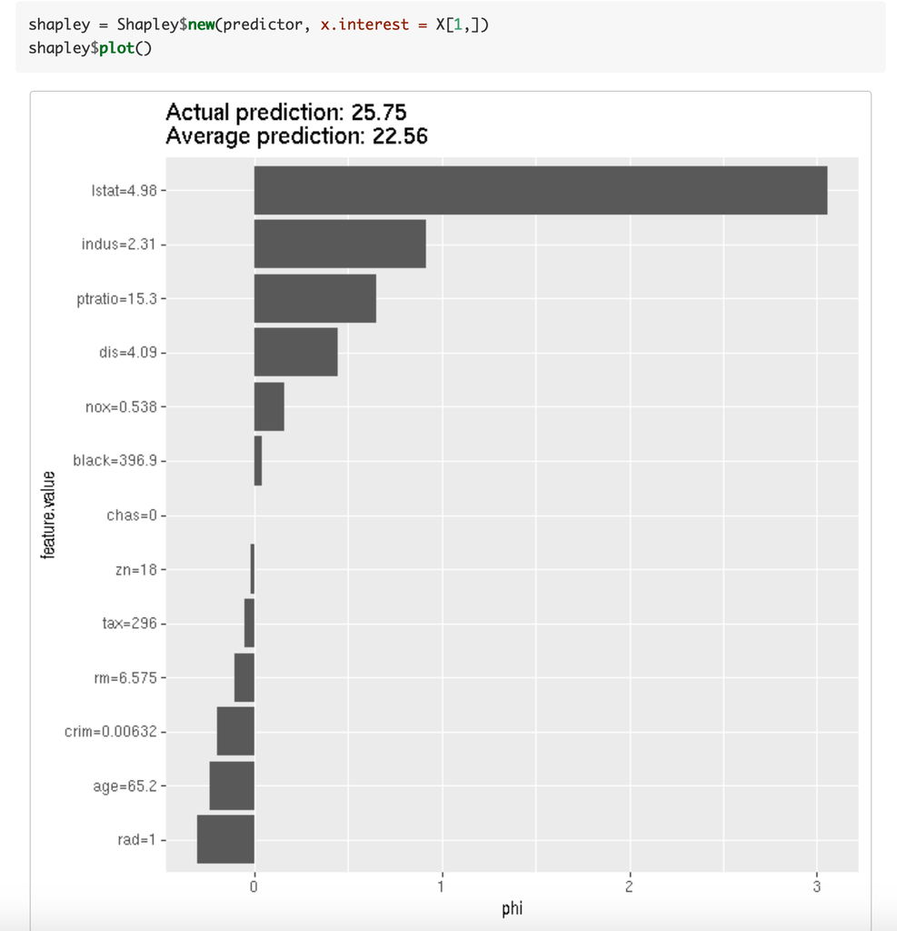

**[xgboostExplainer](https://medium.com/applied-data-science/new-r-package-the-xgboost-explainer-51dd7d1aa211)**

## Recommended readings about SHAP values

Start with *Interpretable Machine Learning* by Christoph Molnar. It addresses well the[Model-Agnostic Methods](https://christophm.github.io/interpretable-ml-book/agnostic.html) and one of its particular cases [Shapley values](https://christophm.github.io/interpretable-ml-book/shapley.html). An outstanding work.

A permutation perspective with examples: [One Feature Attribution Method to (Supposedly) Rule Them All: Shapley Values](https://towardsdatascience.com/one-feature-attribution-method-to-supposedly-rule-them-all-shapley-values-f3e04534983d).

–

Suggested reading

- [New discretization method: Recursive information gain ratio maximization](https://blog.datascienceheroes.com/discretization-recursive-gain-ratio-maximization/)
- [Feature Selection using Genetic Algorithms in R](https://blog.datascienceheroes.com/feature-selection-using-genetic-algorithms-in-r/)
- [Data Science Live Book](http://livebook.datascienceheroes.com/) .